# Assignment1

Hoa Hoang

2/13/2020

## Question Completed

> 15/15

## 1. Summarize Grading

> 1. 4 Assignment (15%)
> 2. Labs (10%)
> - Possible 15 labs
> - Classroom Excercise
> - Grade alloted through drop-boxes and rubrics
> 3. 2 Projects (10%, 1/3 Project 1, 2/3 Project 2)
> 4. Clicker (10%)
> 5. Online Quizes (5%)
> 6. Mid-Terms(20%)
> 7. Final (30%)  
>    Grade is standard, no curve.

## 2. A biologist’s fish data

```r
ddt.df = read.csv("DDT.csv")
head(ddt.df)
```

```
##   RIVER MILE  SPECIES LENGTH WEIGHT DDT
## 1   FCM    5 CCATFISH   42.5    732  10
## 2   FCM    5 CCATFISH   44.0    795  16
## 3   FCM    5 CCATFISH   41.5    547  23
## 4   FCM    5 CCATFISH   39.0    465  21
## 5   FCM    5 CCATFISH   50.5   1252  50
## 6   FCM    5 CCATFISH   52.0   1255 150
```

```r
# m=with(ddt.df, as.numeric((MILE))) # A
# length(unique(m)) #B
```

### a. Make the coplot as the biologist required

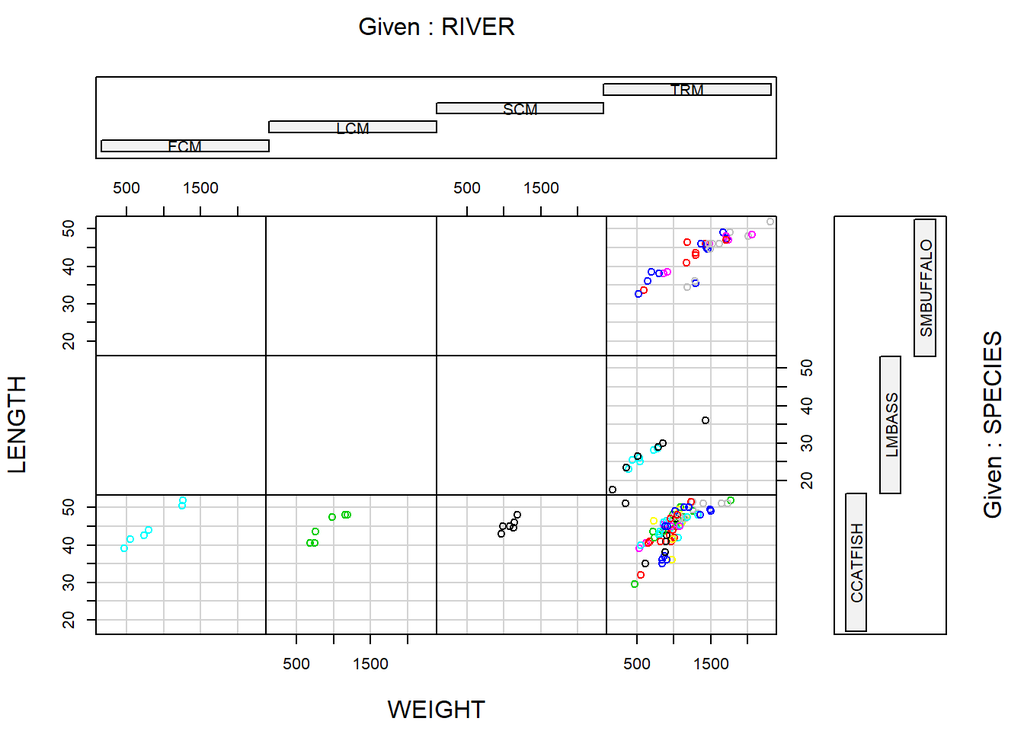

```r
with(ddt.df,coplot(LENGTH ~ WEIGHT | RIVER*SPECIES, col=MILE))
```

### b. Interpret the lower left three conditional plots.

> The three plot show Lenght and Weight of CCATFISH in FCM, LCM, SCM rivers respectiively

### c. What does line A do?

> Line A assign the MILE vector to m, taken from the dataframe

### d. What does line B do?

> Line B display the number of unique for Mile value

### e. Why are the top six plots empty?

> Because there are no LMBASS, SMBUFFLALO in FCM, LCM, SCM rivers

### f. What is the mean value of DDT found in the sample of CCATFISH caught in the FCM river?

```r
FCMnCCATFISH = subset(ddt.df,RIVER=="FCM" & SPECIES=="CCATFISH",)
FCMnCCATFISH
```

```
##   RIVER MILE  SPECIES LENGTH WEIGHT DDT
## 1   FCM    5 CCATFISH   42.5    732  10
## 2   FCM    5 CCATFISH   44.0    795  16
## 3   FCM    5 CCATFISH   41.5    547  23
## 4   FCM    5 CCATFISH   39.0    465  21
## 5   FCM    5 CCATFISH   50.5   1252  50
## 6   FCM    5 CCATFISH   52.0   1255 150
```

```r
### The mean
with(FCMnCCATFISH,mean(DDT))
```

```
## [1] 45
```

## 3. MS 1.14 - pg 8 Quantitative or Qualitative.

### a. Length of maximum span (feet)

> Quantitative

### b. Number of vehicle lanes

> Quantitative

### c. Toll bridge (yes or no)

> Quatitative

### d. Average daily traffic

> Quantitative

### e. Condition of deck (good, fair, or poor)

> Quatitative

### f. Bypass or detour length (miles)

> Quantitative

### g. Route type (interstate, U.S., state, county, or city)

> Quatitative

## 4. MS page 12,13

### a. What are the names of the four random sampling designs (1 simple and 3 more complex).

> simple random sample, stratified random sampling, cluster sampling, and systematic sampling

### b. Give a brief description of each.

> - A simple random sample of n experimental units is a sample selected from the population in such a way that every different sample of size n has an equal chance of selection.
> - Stratified random sampling is a method of sampling that divide the poppulation into smaller group based on thier characteristics first then do random sampling within the group
> - Cluster sampling, is like simple random samling but choose the whole group instead of individual
> - Systematic sampling is systematically selecting every kth experimental unit from a list of all experimental units